# Better supervised evaluation of single-cell data clustering and classification

David Novak

2/21/2022

Supervised evaluation of clustering or classification algorithms amounts to quantifying the difference between predicted labels and a ground truth. In the context of single-cell cytometry, scRNA-seq or CITE-seq data, we often use it to tweak hyperparameters of our methods to achieve high performance on similar unannotated datasets.

This ongoing work sets out to tackle two issues.

Firstly, we provide a tool to assess where the model over-clusters or under-clusters and give population- and cluster-specific scores (to avoid referring solely to a single performance score, such as Rand index of F1 score of clusters bijectively matched to populations).

Secondly, we provide a framework to use taxonomic information about the hierarchy of cell populations present in our data. We use hierarchy-aware versions of commonly used metrics that take these taxonomies into account. This is in contrast to only using leaf nodes of the hierarchy, which is currently commonplace.

We distinguish between two categories of quality-assessment metrics.

The **Rand index** (**RI**) and **adjusted Rand index** (**ARI**) quantify performance of clustering by measuring agreement between predicted cluster numbers and true population labels.

The **accuracy** and **F1 score** quantify performance of classification, comparing predicted population labels to true population labels. However, if we first match cluster numbers to population labels, we can use use these metrics as well.

Crucially, the F1 score of bijectively (1-to-1) matched clusters and populations is routinely used for assessment of clustering quality. This runs the risk of obscuring that *(1)* there are other ways to match clusters to populations (1 population to many clusters, many clusters to 1 population, based on maximising F1 score, precision, recall…) and that *(2)* cluster-population matches in the bijective matching are ignored in the final scoring (this is significant, since there are usually more clusters than annotated populations, leading almost necessarily to ignoring some data in evaluation).

## Jaccard similarity heatmaps

To evaluate clustering from the standpoint of ground-truth label assignment, we can produce Jaccard similarity heatmaps. These are an extension of confusion matrices that quantify overlap between clusters and populations. The heatmap shows results of matching bijectively, matching each cluster to a population (with possible multiple matches per population) and matching each population to a cluster (with possible multiple matches per cluster). The matches are determined so as to maximise the F1 score per match, and the precision, recall and F1 score per match are displayed.

The code below creates synthetic data and produces a Jaccard similarity heatmap.

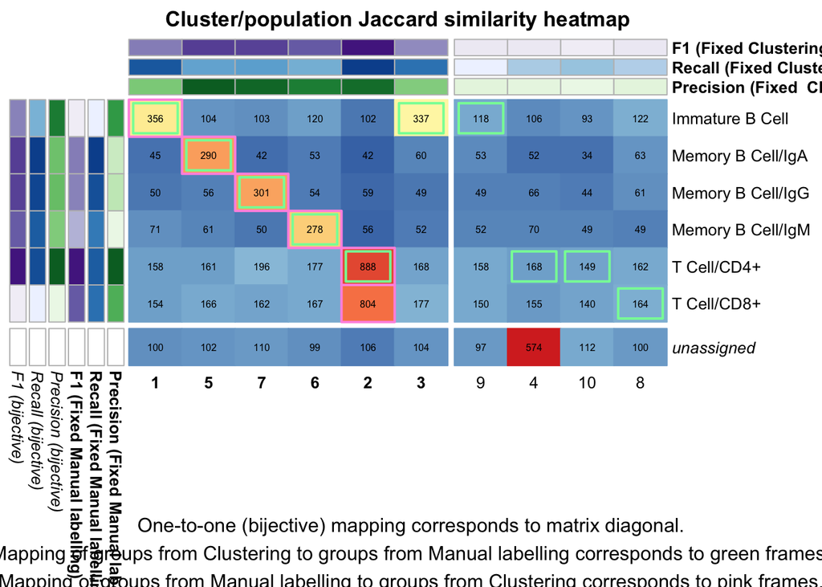

```r
library(hloss)

pops <- c('Immature B Cell', 'T Cell/CD4+', 'T Cell/CD8+', 'Memory B Cell/IgM', 'Memory B Cell/IgA', 'Memory B Cell/IgG', 'unassigned')
n <- 10000 # cell count
nc <- 10 # cluster count
np <- length(pops) # population count

## Simulate perfect clustering
set.seed(42); true <- pops[sample(1:np, size = n, prob = c(2, 3, 3, 1, 1, 1, 2), replace = TRUE)]
pred <- as.factor(true)
set.seed(42); levels(pred) <- sample(1:np, size = np, replace = FALSE)
pred <- as.integer(as.character(pred))

## Split Immature B Cells into two clusters
idcs <- which(true == 'Immature B Cell')
idx_cl <- pred[idcs[1]]
pred[idcs[1:(round(length(idcs)/2))]] <- if (idx_cl > (np - 2)) idx_cl - 1 else idx_cl + 2

## Merge CD4+ and CD8+ into one cluster
pred[true %in% c('T Cell/CD4+', 'T Cell/CD8+')] <- pred[true == 'T Cell/CD4+'][1]

## Introduce random errors
random_rate <- 0.7
s <- round(n * random_rate)
set.seed(2); pred[sample(1:n, size = s, replace = FALSE)] <- sample(1:nc, size = s, replace = TRUE)
true <- as.factor(true)
pred <- as.factor(pred)
j <- hloss::Jacc(c1 = true, c2 = pred, obj = 'f1', title = 'Cluster/population Jaccard similarity heatmap', unassigned = 'unassigned', generate_plot = TRUE, c1_name = 'Manual labelling', c2_name = 'Clustering')
j$Plot
```

## Hierarchy-aware evaluation

A hierarchy of cell types and their subtypes is described by a taxonomic tree. This tree is defined by its topology (shape of the tree) and lengths of branches (inversely proportional to ‘relatedness’ of populations).

The topology describes our understanding of how populations are related (*eg.* every T-cell is a lymphocyte, but there are lymphocytes which are not T-cells). The branch lengths can be set manually (*eg.* the length of branch leading to a child node that represents a rare or elusive population can be made longer than others) or calibratedautomatically using known cell counts associated with each or some nodes of the tree.

### Sample code

We load set up a simple toy hierarchy of lymphocytes in blood.

```r
library(hloss)

nodes <- c(
  'Lymphocyte',
  'Lymphocyte/B Cell',
  'Lymphocyte/B Cell/Immature B Cell',
  'Lymphocyte/B Cell/Memory B Cell',
  'Lymphocyte/B Cell/Memory B Cell/IgM',
  'Lymphocyte/B Cell/Memory B Cell/IgA',
  'Lymphocyte/B Cell/Memory B Cell/IgG',
  'Lymphocyte/T Cell',
  'Lymphocyte/T Cell/CD4+',
  'Lymphocyte/T Cell/CD8+'
)

tax <- CalibratedTaxonomy(
  name = 'Blood Cells',
  paths = nodes
)
```

This creates a tree structure. By default, branch weights are set such that the sum of weights of all branches going from a parent is always `1`, and the weights are distributed uniformly among the branches leading from each parent. (Alternatively, look into the documentation of `CalibratedTaxonomy` to use population sizes for estimating relatedness or use `SetDistancesFromParent` and `SetDistanceToChild` to change branch weights manually.) We call `plot` on the `tax` object to view the full taxonomy.

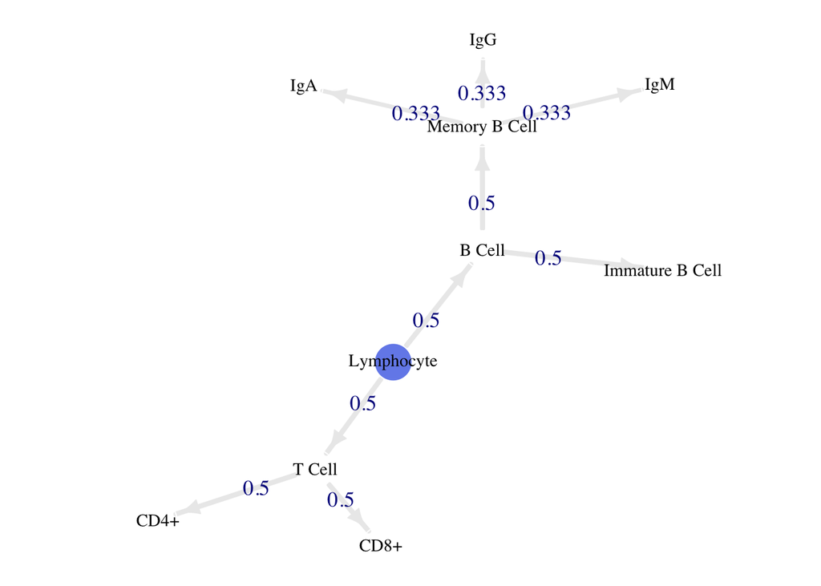

```r
plot(tax)
```

## Distances

To quantify the importance of a match or mismatch between a predicted and true label, we will use distances in this tree. We define a *pair-distance* $p(i,j)$ as the shortest distance from node $i$ to node $j$. Then we define *self-distance* $s(i)$ as the local density of the taxonomic tree in which the node is located.

First, we calculate all pair distances and scale them, so that the values lie in $[0,1]$. Second, each self-distance is calculated from a node’s pair-distances as sum of negative base-2 logarithms of these distances and all the self-distances are again scaled to lie in $[0,1]$.

### Distance-based scoring of classification

Consider the following. If a particular point is assigned an incorrect label of index $x$ instead of the correct label of index $y$, we can quantify this **mismatch** using $p(x,y)$. If a point is assigned the correct label ($x=y$), we can score the **match** using $s(y)$.

This scoring scheme can be used for classifiers using **accuracy** or the **per-match F1 score**. We can also treat clustering problems as classification problems if we first manually match cluster indices to labelled populations. To do this, we can use `hloss:::.BijectiveMatch` to generate one-to-one matches between clusters and populations or `hloss:::.RelaxedMatch` to generate one-to-many or many-to-one matches (especially for over-clustered data) and proceed with evaluation.

For hierarchy-aware accuracy, we use one-minus-pair-distances as penalties for mismatches and self-distances as rewards for matches.

For the F1 score, calculation of precision and recall is adjusted so that the values for true positives (TP), false positives (FP), true negatives (TN) and false negatives (FN) again use the distance values instead of counts.

### Distance-based scoring of clustering

To directly score clustering, without explicitly matching clusters to populations, we use the **Rand index (RI)** or the **adjusted Rand index (ARI)**, derived from the RI. (While the RI takes on a value between $0$ and $1$, the ARI is adjusted for chance, meaning negative values can occur if a clustering is worse than random.) The derivation of hierarchy-aware versions of RI and ARI is slightly more complicated.

To compute the RI, we look at each of the ${2\choose n}$ possible points that can be drawn from our data. We calculate $RI = \frac{a+b}{a+b+c+d}$. $a$ is the count of pairs of points that are predicted to come from the same cluster and belong to the same population (*same-same*). $b$ counts pairs that cluster different and are labelled different (*different-different*). $c$ counts *same-different* and $d$ counts *different-same*. (Thus $a$ and $b$ count matches and $c$ and $d$ count mismatches.)

In the hierarchy-aware RI and ARI, we don’t simply use counts. Instead, we use weights of (mis)matches in the following way.

[output not shown]

The rationales for this weighting (for respective rows of the table) are as follows.

*(a)* Clustering points together correctly is rewarded more in denser regions of the tree.

*(c)* Clustering points together incorrectly is penalised more if they are far apart in the tree.

*(d)* Clustering points apart incorrectly is penalised less in denser regions of the tree.

### Sample code

We proceed by computing all pair- and self-distances for our taxonomy.

```r
ComputeDistances(tax)
```

## Metrics

Multiple metrics can now be deployed to compare a vector of predicted labels and a vector of true labels. If we are evaluating a clustering algorithm, typically the output consists of cluster numbers that are not mapped to cell populations . In that case, we can use `hloss:::.BijectiveMatch` to generate one-to-one matches between clusters and populations or `hloss:::.RelaxedMatch` to generate one-to-many or many-to-one matches and proceed with using population labels instead of cluster numbers.

Preferably, however, we can use the hierarchical RI or ARI, which (as mentioned above) does not require explicit cluster-to-label matching.

We can use the following functions to compute the values of each quality-assessment metric:

`RI` for the Rand index.

`hRI` for the hierarchy-aware Rand index.

`ARI` for the adjusted Rand index.

`hARI` for the hierarchy-aware adjusted Rand index.

`OverallAcc` for accuracy.

`hOverallAcc`for hierarchy-aware accuracy.

`AccPerMatch` for accuracy per cluster-population match.

`hAccPerMatch` for hierarchy-aware accuracy per cluster-population match.

`F1PerMatch` for F1 score per cluster-label match.

`F1PerMatch` for hierarchy-aware F1 score per cluster-label match.

Each of these functions is documents (use eg. `?hRI` to pull up documentation for the `hRI` function.)